# Praca domowa 2

Marek Skok

## Dane

Dane wykorzystane w Pracy domowej 2 dotyczą wyników egzaminów z 3 umiejętności: czytania, pisania i operacji matematycznych. Dodatkowo dostępne są podstawowe informacje o studentach i ich rodzicach. Opis wszystkich kolumn znajduje się również w pliku `README.md`.

| Zmienna | Opis |
| --- | --- |
| **gender** | płeć |
| **race.ethnicity** | pochodzenie etniczne |
| **parental.level.of.education** | wykształcenie rodziców |
| **lunch** | jaki obiad jedli uczniowie w dniu egzaminu |
| **test.preparation.course** | czy uczeń odbył kurs przygotowujący |
| **math.score** | wynik egzaminu z matematyki |
| **reading.score** | wynik egzaminu z czytania |
| **writing.score** | wynik egzaminu z pisania |

## Zadanie 1

Jak wyglądają rozkłady wyników uczniów z trzech przedmiotów (matematyka, czytanie, pisanie)?

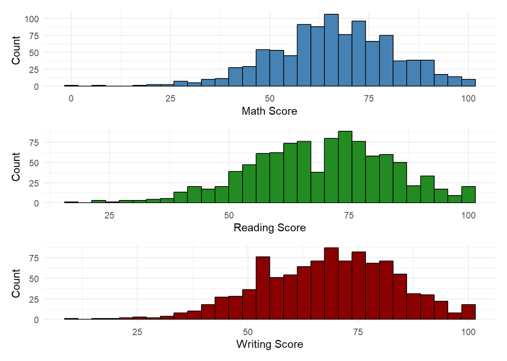

```r
# Tu umieść kod do wygenerowania odpowiedzi do zadania.

math1_plot <- df %>%
  ggplot(aes(x = math.score)) +
  geom_histogram(fill = "steelblue", bins = 30, color = "black") +
  labs(x = "Math Score", y = "Count") +
  theme_minimal()

reading1_plot <- df %>%
  ggplot(aes(x = reading.score)) +
  geom_histogram(fill = "forestgreen", bins = 30, color = "black") +
  labs(x = "Reading Score", y = "Count") +
  theme_minimal()

writing1_plot <- df %>%
  ggplot(aes(x = writing.score)) +
  geom_histogram(fill = "darkred", bins = 30, color = "black") +
  labs(x = "Writing Score", y = "Count") +
  theme_minimal()

math1_plot / reading1_plot / writing1_plot
```

**Komentarz: Wykresy wszystkich trzech przedmiotów są bardzo zbliżone i lekko lewoskośne.**

## Zadanie 2

Czy istnieje zauważalna różnica w wynikach między uczniami i uczennicami?

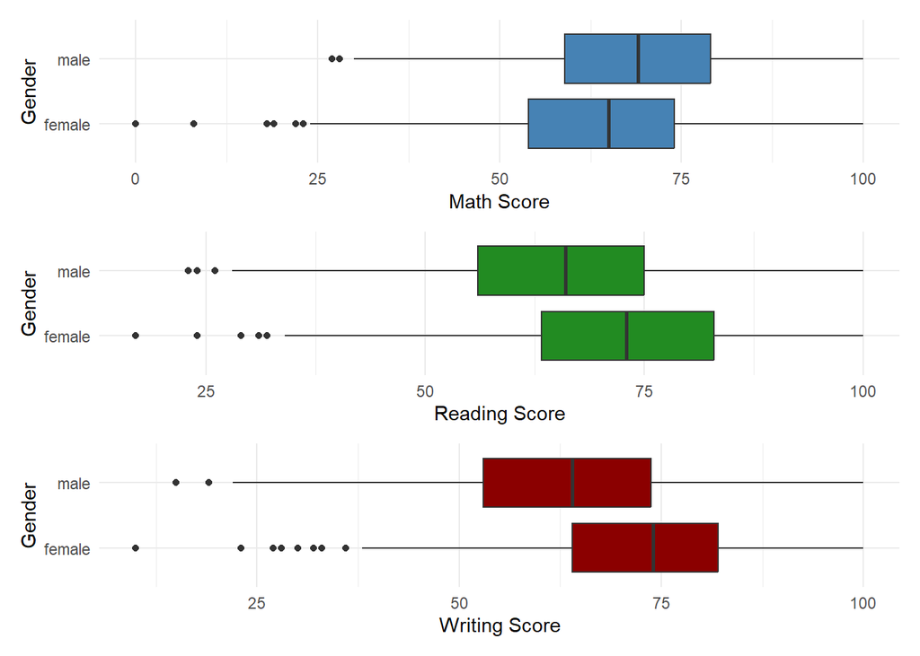

```r
# Tu umieść kod do wygenerowania odpowiedzi do zadania.

math2_plot <- df %>%
  ggplot(aes(x = math.score, y = gender)) +
  geom_boxplot(fill = "steelblue") +
  labs(x = "Math Score", y = "Gender") +
  theme_minimal()

reading2_plot <- df %>%
  ggplot(aes(x = reading.score, y = gender)) +
  geom_boxplot(fill = "forestgreen") +
  labs(x = "Reading Score", y = "Gender") +
  theme_minimal()

writing2_plot <- df %>%
  ggplot(aes(x = writing.score, y = gender)) +
  geom_boxplot(fill = "darkred") +
  labs(x = "Writing Score", y = "Gender") +
  theme_minimal()

math2_plot / reading2_plot / writing2_plot
```

**Komentarz: Mężczyźni są odrobinę lepsi w matematyce, a kobiety są zauważalnie lepsze w pozostałcyh kategoriach.**

## Zadanie 3

Czy uczniowie, którzy ukończyli kurs przygotowawczy, osiągają lepsze wyniki niż pozostali?

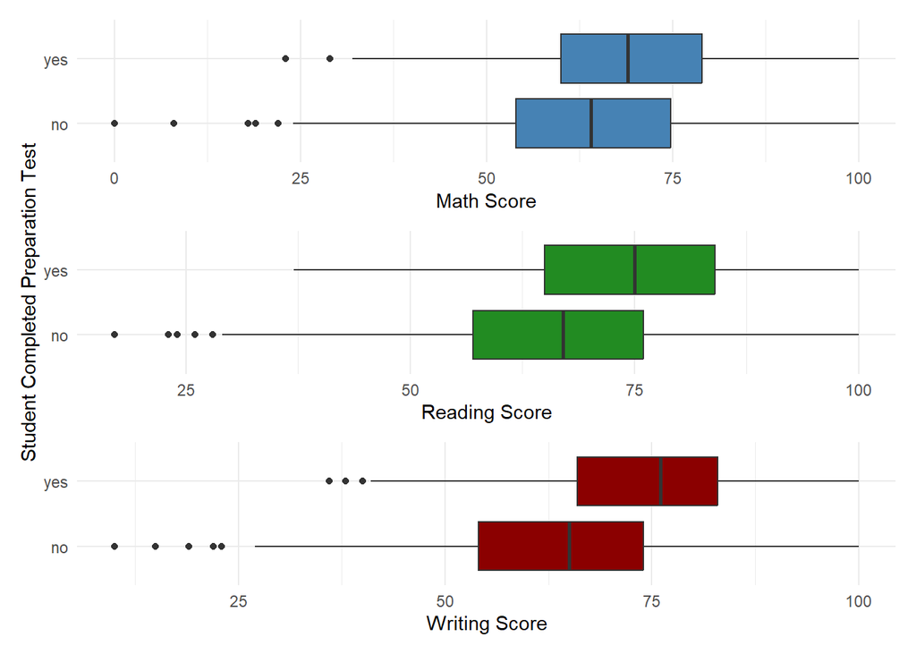

```r
# Tu umieść kod do wygenerowania odpowiedzi do zadania.

df$test.preparation.course = ifelse(df$test.preparation.course == "completed", "yes", "no")

math3_plot <- df %>%
  ggplot(aes(x = math.score, y = test.preparation.course)) +
  geom_boxplot(fill = "steelblue") +
  labs(x = "Math Score", y = "") +
  theme_minimal()

reading3_plot <- df %>%
  ggplot(aes(x = reading.score, y = test.preparation.course)) +
  geom_boxplot(fill = "forestgreen") +
  labs(x = "Reading Score", y = "Student Completed Preparation Test") +
  theme_minimal()

writing3_plot <- df %>%
  ggplot(aes(x = writing.score, y = test.preparation.course)) +
  geom_boxplot(fill = "darkred") +
  labs(x = "Writing Score", y = "") +
  theme_minimal()

math3_plot / reading3_plot / writing3_plot
```

**Komentarz: Tak, we wszystkich kategoriach uczniowie po testach przygotowawczych osiągali średnio wyższe wyniki.**

## Zadanie 4

Jaki jest związek między poziomem wykształcenia rodziców a średnimi wynikami uczniów?

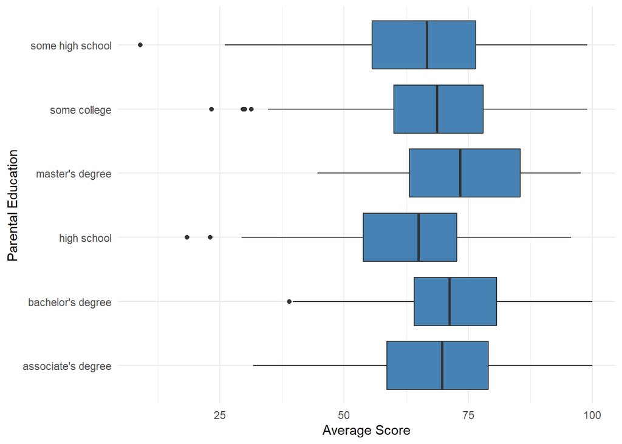

```r
# Tu umieść kod do wygenerowania odpowiedzi do zadania.

df %>%
  mutate(avg.score = rowMeans(cbind(math.score, reading.score, writing.score))) %>%
  ggplot(aes(y = parental.level.of.education, x = avg.score)) +
  geom_boxplot(fill = "steelblue") +
  labs(x = "Average Score", y = "Parental Education") +
  theme_minimal()
```

## Zadanie 5

Czy płeć i wykształcenie rodzica wpływa na wynik z matematyki?

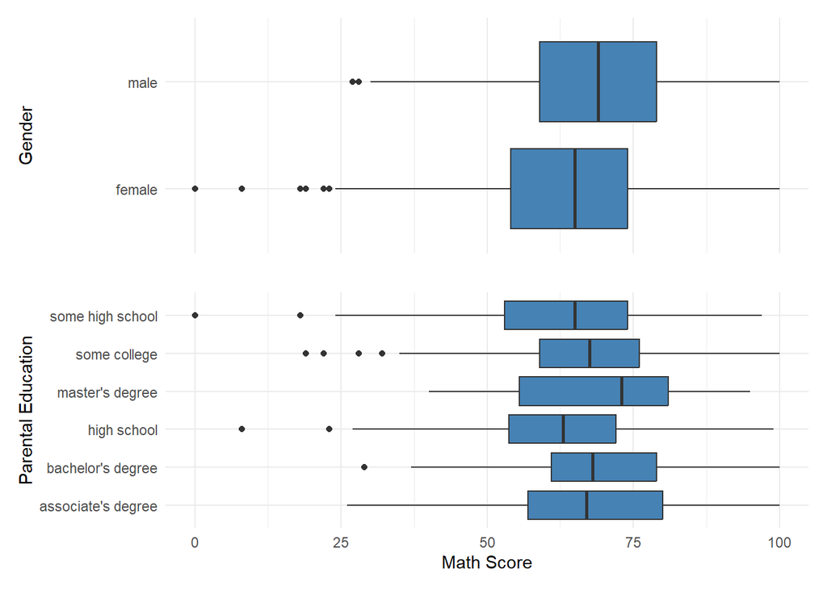

```r
# Tu umieść kod do wygenerowania odpowiedzi do zadania.

math5_plot <- df %>%
  ggplot(aes(x = math.score, y = gender)) +
  geom_boxplot(fill = "steelblue") +
  labs(x = "", y ="Gender") +
  theme_minimal() +
  theme(axis.text.x = element_blank())


math5.2_plot <- df %>%
  ggplot(aes(x = math.score, y = parental.level.of.education)) +
  geom_boxplot(fill = "steelblue") +
  labs(y = "Parental Education", x = "Math Score") +
  theme_minimal()

math5_plot / math5.2_plot
```

**Komentarz: Tak, płeć i wykształcenie rodziców wpływają na wyniki w matematyce. Możemy zauważyć to najlepiej u uczniów z rodzicami o wykształceniu wyższym.**

## Zadanie 6 Czy istnieje zależność między wynikami z matematyki a wynikami z czytania lub pisania?

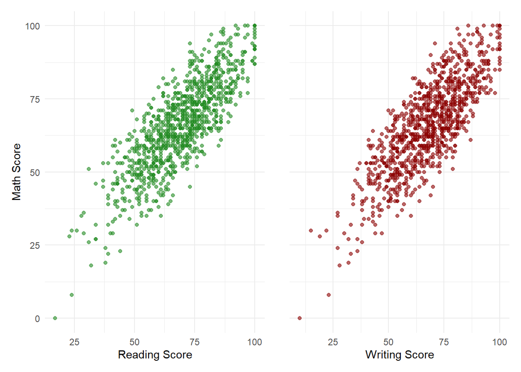

```r
# Tu umieść kod do wygenerowania odpowiedzi do zadania.

z6.1 <- df %>%
  ggplot(aes(x = reading.score, y = math.score)) +
  geom_point(color = "forestgreen", alpha = 0.6) +
  labs(y = "Math Score", x = "Reading Score") +
  theme_minimal()

z6.2 <-  df%>%
  ggplot(aes(x = writing.score, y = math.score)) +
  geom_point(color = "darkred", alpha = 0.6) +
  labs(y = "", x = "Writing Score") +
  theme_minimal() +
  theme(axis.text.y = element_blank())

z6.1 + z6.2
```

**Komentarz: Istnieje, im uczeń jest lepszy z matematyki tym lepszy jest z pisania i czytania.**